# Introduction

Swedish Biodiversity Data Infrastructure

# Accessing data from SBDI

To retrieve data from the Swedish Biodiversity Data Infrastructure, the SBDI4R package can be used.

To learn more about using the SBDI4R package, please look at the vignette:

https://biodiversitydata-se.github.io/SBDI4R

[figure not shown]

Besides the SBDI4R package, please look at these SBDI web resources:

- https://biodiversitydata.se/
- https://tools.biodiversitydata.se/
- https://docs.biodiversitydata.se/

These resources may be of interest too:

- Sensitive Data service: https://sds.biodiversitydata.se/
- API documentation webapp: https://api.biodiversitydata.se/
- Dashboard: https://dashboard.biodiversitydata.se/
- Regions webapp: https://regions.biodiversitydata.se
- Molecular data: https://molecular.biodiversitydata.se/
- Biocollect: http://biocollect.biodiversitydata.se/
- Ecodata: https://ecodata.biodiversitydata.se/documentation/index

# Quick examples of SBDI4R usage

Let’s illustrate how to do this through some examples.

To begin with, lets say that we are interested in studying occurrences of berries that are spread by birds - such as “Prunus avium” - sweet cherries.

## How many cherries are there?

We start by getting a total record count given the latin name “Prunus avium”.

```r
library(SBDI4R)
binomen <-  "Prunus avium"

n_records <- occurrences(
  taxon = binomen,
  email = "sbdi4r-test@biodiversitydata.se",
  record_count_only = TRUE, use_layer_names = FALSE)
message("Total record cound for ", binomen, " is ", n_records)
```

```
## Total record cound for Prunus avium is 22158
```

## Occurrence records

To retrieve the occurrence records we can do this:

```r
library(tidyverse)
library(DT)

df <- occurrences(taxon = binomen,
  email = "sbdi4r-test@biodiversitydata.se",
  download_reason_id = 10, use_layer_names = FALSE)

# inspect the occurrence data as text table
occ <- head(df$data, 100)
as_tibble(occ)
```

```
## # A tibble: 100 x 58
##    id           dataResourceID dataResourceName        licence catalogueNumber
##    <chr>        <chr>          <chr>                   <chr>   <chr>
##  1 fedb8883-c8… dr2            Lund Botanical Museum … ""      2093727
##  2 ea1f0fb6-3a… dr23           Oskarshamn herbarium (… "CC0"   92656
##  3 bc6673f1-3f… dr2            Lund Botanical Museum … ""      2094239
##  4 b7e95bf8-91… dr17           National Wetland Inven… "CC0"   PRUN AVI:M03B8J0…
##  5 b2fa3f21-c0… dr2            Lund Botanical Museum … ""      1709776
##  6 9fe07eb1-af… dr2            Lund Botanical Museum … ""      1696254
##  7 8df4bc05-9e… dr2            Lund Botanical Museum … ""      2093791
##  8 857366be-a8… dr36           Botany (UPS) - Version… "CC0"   V-037533
##  9 7a46de9f-47… dr36           Botany (UPS) - Version… "CC0"   V-037535
## 10 78160969-cd… dr36           Botany (UPS) - Version… "CC0"   V-101211
## # … with 90 more rows, and 53 more variables: taxonConceptLsid <int>,
## #   scientificNameOriginal <chr>, commonNameOriginal <chr>,
## #   scientificName <chr>, rank <chr>, commonName <lgl>, kingdom <chr>,
## #   phylum <chr>, class <chr>, order <chr>, family <chr>, genus <chr>,
## #   species <chr>, subspecies <lgl>, institutionCode <chr>,
## #   collectionCode <chr>, locality <chr>, latitudeOriginal <dbl>,
## #   longitudeOriginal <dbl>, geodeticDatumOriginal <lgl>, latitude <dbl>,
## #   longitude <dbl>, coordinateUncertaintyInMetres <dbl>, country <chr>,
## #   state <lgl>, minimumElevationInMeters <dbl>,
## #   maximumElevationInMeters <dbl>, minimumDepthInMeters <lgl>,
## #   maximumDepthInMeters <lgl>, individualCount <int>, year <int>, month <int>,
## #   day <int>, verbatimEventDate <lgl>, basisOfRecord <chr>,
## #   basisOfRecordOriginal <chr>, sex <lgl>, preparations <chr>,
## #   taxonomicQuality <lgl>, locationQuality <lgl>,
## #   assumedPresentOccurrenceStatus <lgl>, countryCoordinateMismatch <lgl>,
## #   firstOfMonth <lgl>, firstOfYear <lgl>, geodeticDatumAssumedWgs84 <lgl>,
## #   idPreOccurrence <lgl>, incompleteCollectionDate <lgl>,
## #   invalidCollectionDate <lgl>, recordedByUnparsable <lgl>,
## #   uncertaintyInPrecision <lgl>, uncertaintyRangeMismatch <lgl>,
## #   unrecognisedCollectionCode <lgl>, unrecognisedInstitutionCode <lgl>
```

```r
# ...or as HTML table with just a few of the relevant columns

cherries_df <- occ %>%
  select(catalogueNumber, institutionCode, collectionCode, locality)

datatable(cherries_df)
```

|  | catalogueNumber | institutionCode | collectionCode | locality |
| --- | --- | --- | --- | --- |
| 1 | 2093727 | LD | General | Hålberget |
| 2 | 92656 | BMO | OHN | Sundby, Brottby |
| 3 | 2094239 | LD | General | No locality information available |
| 4 | PRUN AVI:M03B8J01:1:0:0:P:LB | NV | VMI |  |
| 5 | 1709776 | LD | General | Seckau |
| 6 | 1696254 | LD | General | Seckau |
| 7 | 2093791 | LD | General | No locality information available |
| 8 | V-037533 | UPS | BOT | Lukastorp |
| 9 | V-037535 | UPS | BOT | Degeberg, cult |
| 10 | V-101211 | UPS | BOT |  |

[output cut: 90 more lines]

To see metadata related to the dataset and understand how to reference and quote it, we can do this:

```r
meta <- as_tibble(df$meta)
meta
```

```
## # A tibble: 0 x 10
## # … with 10 variables: UID <lgl>, Name <lgl>, DOI <lgl>, Citation <lgl>,
## #   Rights <lgl>, More.Information <lgl>, Data.generalisations <lgl>,
## #   Information.withheld <lgl>, Download.limit <lgl>,
## #   Number.of.Records.in.Download <lgl>
```

```r
# show citation info
citation <- as_tibble(meta$Name, meta$Citation)
datatable(citation)
```

|  | value |
| --- | --- |

## More examples

If you wish you can define your own list of species and automate the lookup of the total number of records for each.

The example below illustrates this:

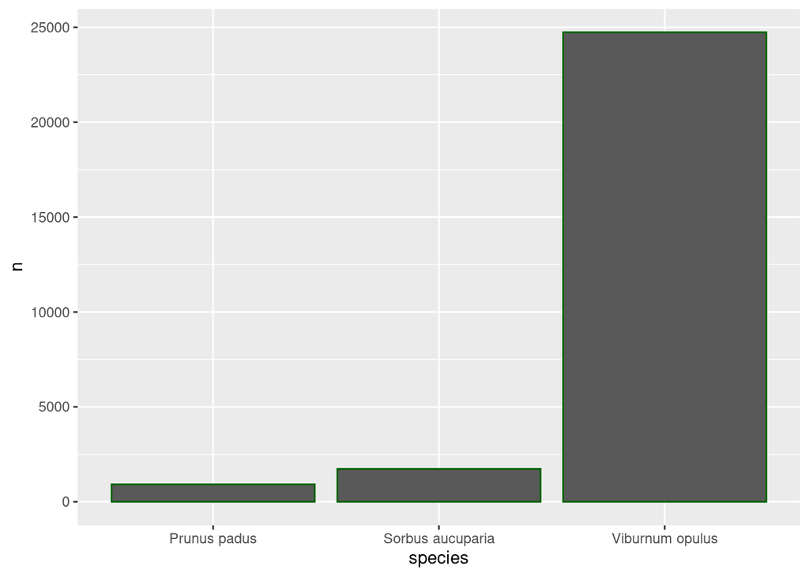

```r
library(purrr)
library(ggplot2)

species_list <- c(
  "Prunus padus",  # hägg
  "Sorbus aucuparia",  # rönn
  "Viburnum opulus"  # olvon
  )

n_sbdi <- function(binomen) {

  n <- occurrences(taxon = binomen,
    email = "sbdi4r-test@biodiversitydata.se",
    record_count_only = TRUE, use_layer_names = FALSE)

  res <- tibble(species = binomen, n = n)

  return (res)
}

comparison_n <- map_df(species_list, n_sbdi)

ggplot(data = comparison_n, aes(x = species, y = n)) +
  geom_bar(color = "darkgreen", stat = "identity")
```

You can use this technique for record count comparisons of say various invasive species in a similar way:

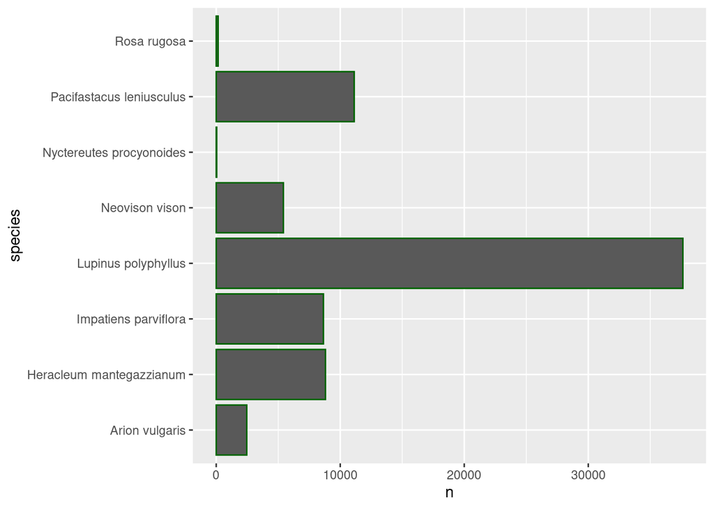

Now, some further ideas of topics to study:

How would you create some reproducible open research work that studies the hypothesis whether the known presence of `Ranunculus glacialis` changes by moving up the mountains when the climate gets warmer?

Are there any signs that `Heracleum mantegazzianum` - Jätteloka is the Swedish vernacular name - is increasing again?